# Instagram food reels on my feed

## Introduction

Earlier in the year, I was tasked to create a report based on something I found interesting and log data over a period of time. I decided to create a report about the frequency of food reels (short, vertical videos which covered content about food eg. recipes, restaurant recommendations/reviews, mukbangs, etc) seen on Instagram whenever I browsed the site or app.

I did this by answering a Google form whenever I finished browsing Instagram after a period of time. The form recorded whether I saw a food reel on Instagram (Yes/No), the number of food reels I saw on Instagram and whether I interacted with any of the food reels (like, comment, share etc) I saw. The data collected was done from March 25 to March 29 and had a total of 20 responses.

Then a couple months later, I was tasked to create a visual data story based on the same Google form and data I used for the report. So, I collected some new data and decided that the the purpose of this visual data story is to explore and visualise the number food reels seen on my Instagram feed per day.

The data collected for this visual dat story was done by answering a Google form from May 7 to 13 whenever I was “visiting” (open) or “left” the Instagram. When I chose that I was leaving Instagram, it recorded whether I saw an Instagram food reel or not, the number of food reels I saw on Instagram and if I interacted with the food reels I saw or not.

## Data findings 1

Before investigating the number of Instagram food reels seen on my Instagram feed per day, I wanted to visualise the hours I spent on instagram per day. This is because the time I spend on Instagram would related to how many Instagram food reels I viewed per day. Using the data collected from May 7 to 13, the hours I spent on instagram per day was about:

- 3 hours on May 7th
- 5 hours on May 9th
- 11 hours on May 10th
- less than an hour on May 11th
- 7 hours on May 12th
- 10 hours on May 13th.

These results were reflected on the graph below

## Graph 1 and Disscussion

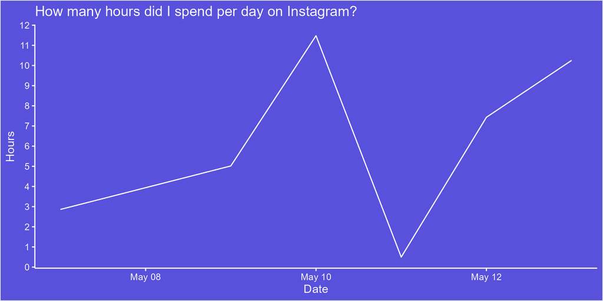

According to the line graph recording the hours I spend on Instagram, the most notable points are as follows, about 3 hours on May 7th, about 5 hours on May 9th, about 11 hours on May 10th, less than an hour on May 11th, about 7 hours on May 12th and about 10 hours on May 13th.

These results indicate that the day I spent the most hours on Instagram was May 10th and conversely, the day I spent the least hours on Instagram was May 11th. *Please note I excluded the data from March because I didn’t log the times I visited and left Instagram and that there was no logged data for May 8th, hence why it wasn’t mentioned.*

## Data findings 2

Using the data collected from from March 25 to 29 it was reported that the total food reels seen per day was:

- 8 food reels on March 25
- 46 food reels on March 26
- 0 food reels on March 27
- 21 food reels on March 28
- 5 food reels on March 29

These results were relfected in the graph below.

## Graph 2 and Disscussion

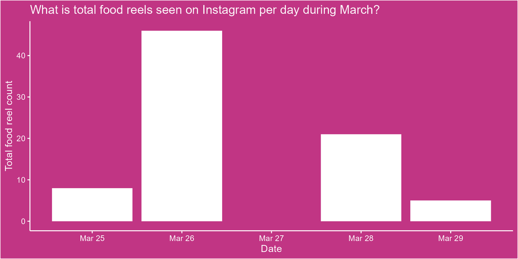

According to the bar graph recording the total reels seen on Instagram during March 25 to 29, it was reported that I saw a total of 8 food reels on March 25, 46 food reels on March 26, 0 on March 27, 21 food reels on March 28 and 5 food reels on March 29.

These results indicate that the day I saw the most food reels was on March 26 and conversely, the day I saw the least amount of food reels was March 27, the next day. This also suggests that on March 26 and 28 I spent a lot more time on Instagram than on March 25 and 29. As the total food reels seen for March 26 and 28 were the largest. For March 26 in particular, the large total of food reels seen is due to the values “10” and “23” being logged that day and is shown in the table below. *Please note that the variable “Total food reels seen” on the graph is a sum of the values in the “number_of_food_reels_seen” variable and that the table shown below is only a snippet of all the data.*

| Timestamp | number_of_food_reels_seen |
| --- | --- |
| 26/03/2025 16:13:38 | 10 |
| 26/03/2025 16:48:20 | 23 |

## Data findings 2.1

Using the data collected from May 7 to 13 it was reported that the total food reel count per day was:

- 10 food reels on May 7
- 0 food reels on May 8
- 9 food reels on May 9
- 10 food reels on May 10
- 3 food reels on May 11
- 7 food reels on May 12
- 17 food reels on May 13

These results are reflected in the graph below.

## Graph 2.1 and Disscussion

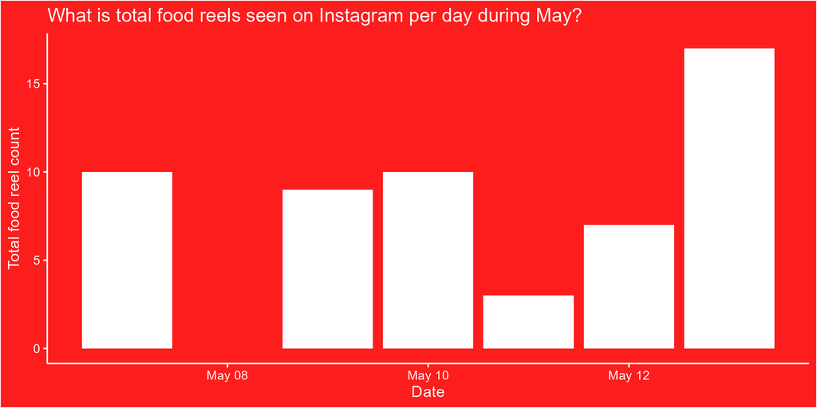

According to the bar graph recording the total reels seen on Instagram during May 7 to 13 it was reported that I saw a total food reel count of 10 food reels on May 7, 0 food reels on May 8, 9 food reels on May 9, 10 food reels on May 10, 3 food reels on May 11, 7 food reels on May 12 and 17 food reels on May 13.

These results indicated that the most food reels I saw on one day was May 13 and conversely, the day I saw the least amount of food reels was May 8. Furthermore, these findings line up with the results from “Data findings 1” as May 13 had the second highest hours spent on Instagram recorded and there was no logged date for May 8th. Additionally, compared to the data in March, the total number of food reels seen are much more spread out.

## Data findings 3

After I finished exploring the number Instagram food reels seen on my feed per day I decided to explore whether or not I interacted with the food reels I saw on my Instagram.

[figure not shown]

According to the dot plot graphing my interaction presence (‘Yes’, ‘No’) on a food reels I saw from March 25 to March 29, I interacted (interaction presence = ‘Yes’) with 9 out of the 11 the food reels I saw during March 25 to March 29. The highest number of interactions was 4 on March 26 and the lowest number of interactions was 1 on March 28.

According to the dot plot graphing my interaction presence on a food reels I saw from March 25 to March 29, there was 11 data points where I saw a food reel and I interacted with 9 of them. The highest number of interactions was 4 on March 26 and the lowest number of interactions was 1 on March 28. This suggest I am more thank likely to interact with an Instagram food reel.

*Please note the reason why the number of food reels from this graph is not the same as data findings 2 or graph 2 is because the data for this graph was filtered to select for data points where I saw a food reel.*

## Data findings 3.1

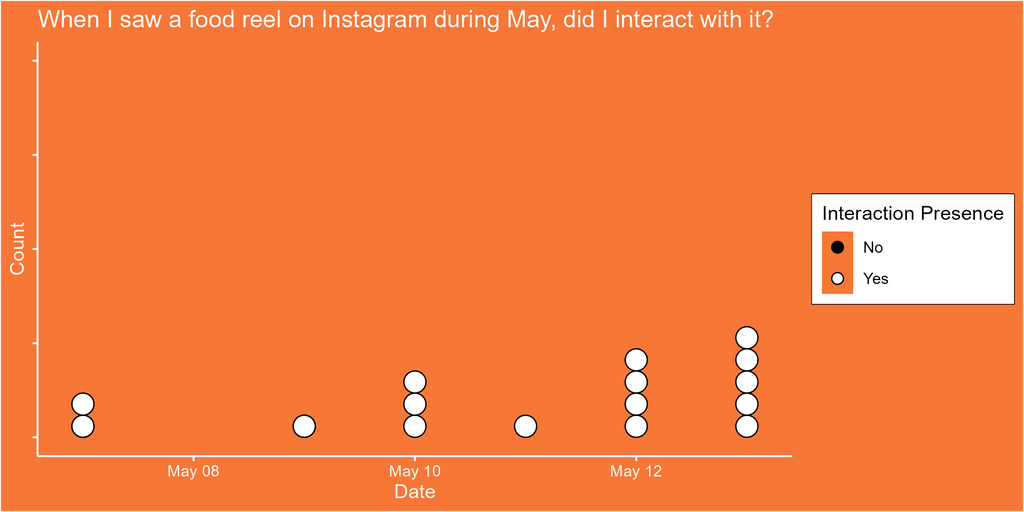

According to the dot plot graphing my interaction presence on a food reels I saw from May 7 to May 13, I interacted with all the 16 food reels I saw. When comparing this with data from March, this means I have shifted from mostly interacting with food reels whenever I see them to always interacting with them.

*Please note the reason why the number of food reels from this graph is not the same as data findings 2.1 or graph 2.1 is because the data for this graph was filtered to select for data points where I saw a food reel.*